# Homework 2 | Solutions

Solutions to Homework 2

Omer Yalcin  
2022-03-11

## Question 1

```r
data(UN11)
```

### 1.1.2.

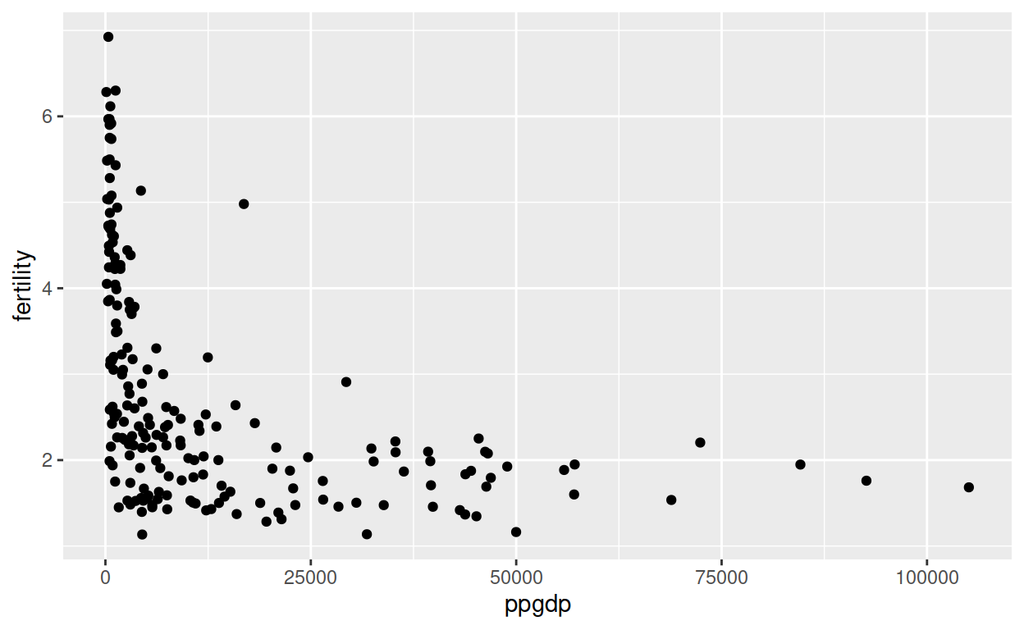

```r
ggplot(data = UN11, aes(x = ppgdp, y = fertility)) +
  geom_point()
```

A straight line is not appropriate, because the relationship has an L-shaped structure.

### 1.1.2

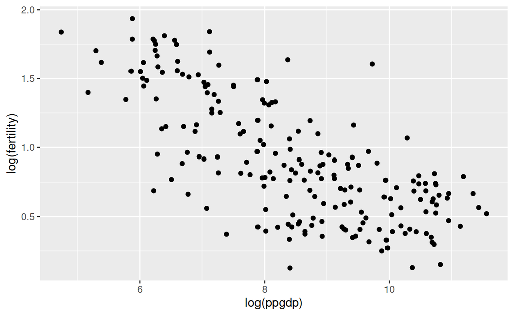

```r
ggplot(data = UN11, aes(x = log(ppgdp), y = log(fertility))) +
  geom_point()
```

Yes, now a simple linear regression model is more plausible. We can imagine a negative-sloped straight line going through those points.

## Question 2

### (a)

The conversion from USD to British pound will mean the numerical value of the response will be divided by 1.33. To offset that, the slope will also become divided by 1.33.

### (b)

Correlation will not change because it is a standardized measure that is not influenced by the unit of measurement.

Both outcomes can easily be shown via simulation.

## Question 3

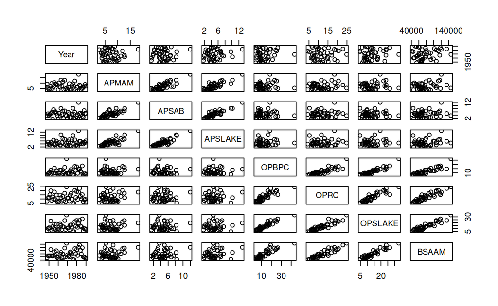

```r
data(water)
pairs(water)
```

1. `Year` appears to be largely unrelated to each of the other variables
2. the three variables starting with “O” seem to be correlated with each other, meaning that all the plot including two of these variables exhibit a dependence between the variables that is stronger than the dependence between the “O” variables and other variables. The three variables starting with “A” also seem to be another correlated group
3. `BSAAM` is more closely related to the “O” variables than the “A” variables

## Question 4

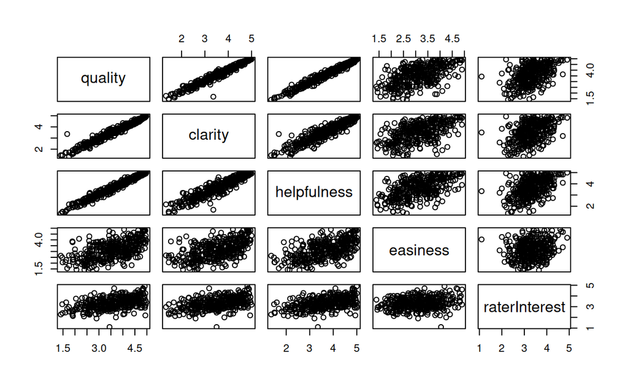

```r
data(Rateprof)
pairs(Rateprof[,c('quality', 'clarity', 'helpfulness',
                  'easiness', 'raterInterest')])
```

The very strong pair-wise correlation among quality, clarity, and helpfulness is very striking. easiness is also correlated fairly highly with the other three. raterInterest is also moderately correlated, but raters almost always say they are at least moderately interested in the subject. Overall, the results might show that people don’t necessarily distinguish all these dimensions very well in their minds—or that professors that do one in one dimension tend to do well on the others too.

## Question 5

### a

One way of visually representing the relationship between religiosity and political ideology is as follows (and there are other ways). As we go towards bars to the right (more religiousity), we see lighter colors pop up (more conservatism)

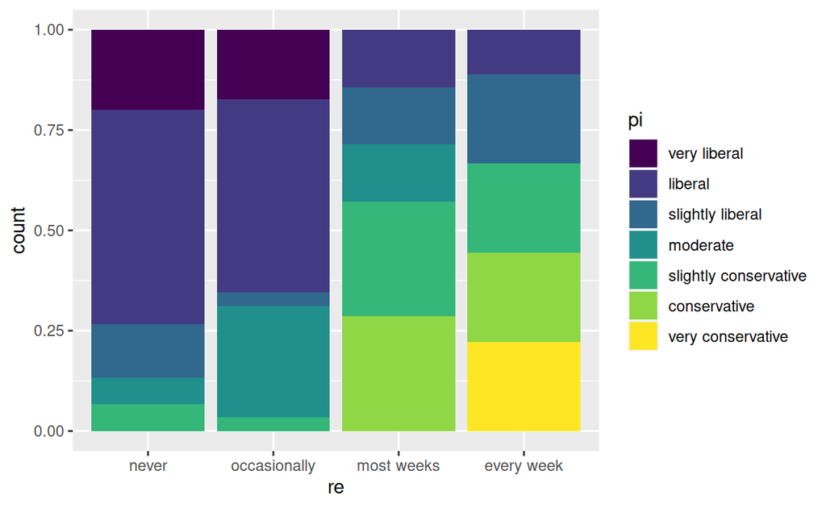

```r
data(student.survey)
ggplot(data = student.survey, aes(x = re, fill = pi)) +
    geom_bar(position = "fill")
```

The relationship between high school GPA and hours of watching TV can be shown with a good old scatter plot.

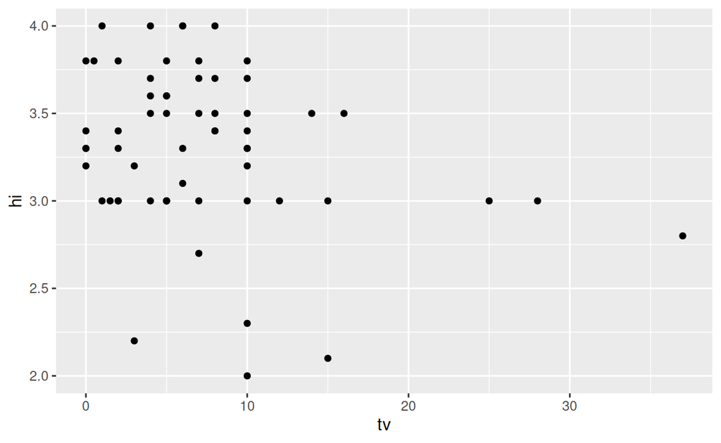

```r
ggplot(data = student.survey, aes(x = tv, y = hi)) +
  geom_point()
```

### b

We can get some descriptive statistics with:

```r
summary(student.survey[,c('pi', 're', 'hi', 'tv')])
```

```
                     pi                re           hi
 very liberal         : 8   never       :15   Min.   :2.000
 liberal              :24   occasionally:29   1st Qu.:3.000
 slightly liberal     : 6   most weeks  : 7   Median :3.350
 moderate             :10   every week  : 9   Mean   :3.308
 slightly conservative: 6                     3rd Qu.:3.625
 conservative         : 4                     Max.   :4.000
 very conservative    : 2
       tv
 Min.   : 0.000
 1st Qu.: 3.000
 Median : 6.000
 Mean   : 7.267
 3rd Qu.:10.000
 Max.   :37.000
```

### c

Dealing with ordinal variables in linear regression is a difficult problem. We’ll just go ahead and assume that we can just convert them to numeric and use them. This would be done for political ideology and religiosity. High school GPA and hours of TV are already continuous.

```r
m1 <- lm(as.numeric(pi) ~ as.numeric(re),
         data = student.survey)
m2 <- lm(hi ~ tv, data = student.survey)
stargazer(m1, m2, type = 'text',
          dep.var.labels = c('Pol. Ideology', 'HS GPA'),
          covariate.labels = c('Religiosity', 'Hours of TV')
          )
```

```
==========================================================
                                  Dependent variable:
                              ----------------------------
                               Pol. Ideology     HS GPA
                                    (1)            (2)
----------------------------------------------------------
Religiosity                       0.970***
                                  (0.179)

Hours of TV                                     -0.018**
                                                 (0.009)

Constant                          0.931**       3.441***
                                  (0.425)        (0.085)

----------------------------------------------------------
Observations                         60            60
R2                                 0.336          0.072
Adjusted R2                        0.324          0.056
Residual Std. Error (df = 58)      1.345          0.447
F Statistic (df = 1; 58)         29.336***       4.471**
==========================================================
Note:                          *p<0.1; **p<0.05; ***p<0.01
```

Religiosity is positively and statistically significantly (at the 0.01 significance level) associated with conservatism.

Hours of TV is negatively and statistically significantly (at the 0.05 significance level) associated with High School GPA. Watching an average of 1 more hour of TV per week is associated with a 0.018 decline in High School GPA.

## Question 6

Regression toward the mean implies that extreme values will always occur by chance and in a next iteration of the test / experiment, those observations’ expected value will still be whatever the previous mean was. In this sense, they’re expected to *regress* toward the mean.

In this example, the tutored students might have been chosen from those who performed very poorly by chance, and the *improvement* might just be an artifact of regression toward the mean.